# STA237A Hw7

Eric Kalosa-Kenyon

22 October 2017

Abstract

In this assignment, a practical time series fit is considered and a proof of MSE for a simple MA(1) process is presented.

# Fitting a time series

## Take a look at the data

```r
df = read.table("./dla.txt")
colnames(df) = c("X")
ns = dim(df)
n = ns[1]
rownames(df) = 1:n
head(df)
```

```
##            X
## 1 -2.0996926
## 2  0.1710076
## 3  1.7466976
## 4  2.8652382
## 5  2.6622350
## 6  1.5362931
```

## Plot the data

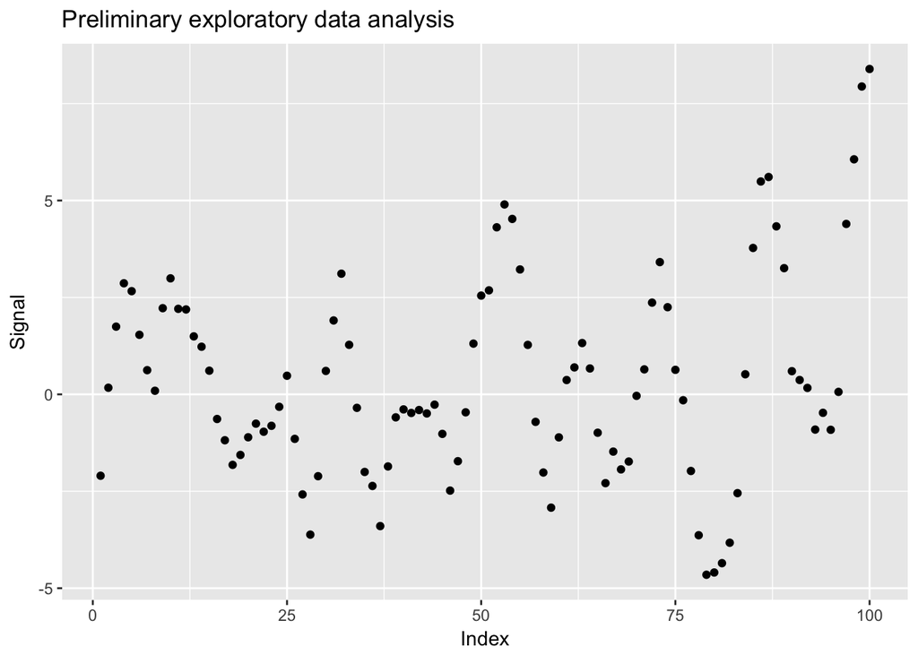

```r
library(ggplot2)
plt = ggplot(df) + geom_point(aes(1:n, X)) +
    labs(title="Preliminary exploratory data analysis",
         x="Index", y="Signal")
plt
```

## Fit an autoregressive process to the data

```r
library(stats)  # includes ar.ols(), the timeseries fit subroutine
dla.ar = ar.ols(df$X)
dla.pred = predict(dla.ar, n.ahead = 2)
```

```
## Warning in object$var.pred * vars: Recycling array of length 1 in array-vector arithmetic is deprecated.
##   Use c() or as.vector() instead.
```

```r
dla.pred.v = dla.pred$pred
```

The predicted values are $\hat{X}_{101}=6.9736033$ and $\hat{X}_{102}=4.5462629$. Notice that the `ar.ols()` fitting function raises a warning. This may indicate a potential loss of accuracy and/or stability in the numerical methods used to fit the OLS, and caution is suggested using these results until the warning is resolved.

## Compare to truth

Given that the true values for times 101 and 102 are $X_{101}=5.36852$ and $X_{102}=1.834852$, the relative errors for the predictions made using `ar.ols()` in the preceeding subsection are

$$\frac{|\hat{X_{101}}-X_{101}|}{|X_{101}|} = 0.2989806 \quad
\frac{|\hat{X_{102}}-X_{102}|}{|X_{102}|} = 1.4777273$$

# Properties of MA(1): $X_t=Z_t+\theta Z_{t-1}$

## Minimum mean square error estimator

In this subsection, the minimum mean square error one-step estimator based on the infinite past is developed.

First, notice that the $MA(1)$ process $(X_t\mid t\in T)$ is mean 0 and stationary. Furthermore, its autocovariance function is defined as follows:
$$\gamma_X(h) =
\begin{cases}
(1+\theta^2)\sigma^2 &\text{if } h=0\\
\theta\sigma^2 &\text{if } h=1\\
0 &\text{if } h>1\\
\end{cases}$$
so $\gamma_X(0)>0$ and $\underset{h\rightarrow\infty}{\text{lim}}\gamma_X(h)=0$. Hence, we can invoke the Innovation Algorithm and follow Ex 5.2.1 on p173 of Brockwell & Davis (2nd ed) to deduce that
$$\begin{split}
\theta_{nj}&=0 \text{ for } j>1,\\
\theta_{n1}&=\nu_{n-1}^{-1}\theta\sigma^2\\
\nu_0&=(1+\theta^2)\sigma^2\\
\nu_n&=(1+\theta^2-\nu_{n-1}^{-1}\theta^2\sigma^2)\sigma^2
\end{split}$$
Letting $r_n=\nu_n/\sigma^2$,
$$\hat{X}_{n+1}=\frac{\theta}{r_{n-1}}(X_n-\hat{X}_n)$$$
Note that $MSE(\hat{X}_{n+1})=\nu_{n+1}$ which converges rapidly to $\sigma^2$. This is also verifiable using the $MSE=Var+Bias^2$ identity, but this expansion is left to the curious reader.

## Truncated estimator

As deduced on p184 Brockwell & Davis (2nd ed), the truncated estimator for an $MA(1)$ process is
$$X^\star_{n+1}=-\sum_{j=0}^{n}(-\theta)^{j+1}X_{n-j}$$
Notice that $E((X_{n+1}-X^\star_{n+1})^2) = E((\sum_{j=0}^n(-\theta)^jX_{n+1-j})^2)$. The structure of $\gamma_X(h)$ forces $\Gamma_n$ to be tridiagonal i.e. the $E(X_{k}X_{k+l}) \text{ for } l>1$ terms in the above sum are uniformly 0. Hence, the above sum works out to the expected value of the elementwise sum of the following outer product:
$$\left( \begin{array}{ccccc}
X_{n+1}X_{n+1} & X_{n+1}(-\theta)X_{n} & 0 & 0 & \dots \\
(-\theta)X_{n}X_{n+1} & (-\theta)^2X_{n}X_{n} & (-\theta)X_{n}(-\theta)^2X_{n-1} & 0 & \dots \\
0 & (-\theta)^2X_{n}X_{n-1} & (-\theta)^2X_{n-1}(-\theta)^2X_{n-1} & (-\theta)^2X_{n-1}(-\theta)^3X_{n-2} & 0 \\
\vdots & 0 & \dots & \dots & X_1X_1\theta^{2n}
\end{array} \right)$$
whose expectation is calculated trivially using the already-obtained autocovariance function $\gamma_X(h)$:
$$=\sigma^2
\left( \begin{array}{ccccc}
(\theta^2+1) & -\theta^2 & 0 & 0 & \dots \\
-\theta^2 & \theta^2(\theta^2+1) & -\theta^4 & 0 & \dots \\
0 & -\theta^4 & \theta^4(\theta^2+1) & -\theta^6 & 0 \\
\vdots & \dots & \dots & \dots & \vdots \\
0 & \dots & -\theta^{2n-2} & \theta^{2(n-1)}(\theta^2+1) & -\theta^{2n} \\
0 & \dots & 0 & -\theta^{2n} & \theta^{2n}(\theta^2+1)
\end{array} \right)$$
The elementwise sum of the above matrix works out to $\sigma^2(1+\theta^{2n+2})$. Notice that, in the case of an $MA(1)$ process as is considered here, the truncated 1-step forecast $X_{n+1}^\star$ has a slightly larger $MSE$, but that its $MSE$ approaches that of the minimum mean square estimator calculated in the preceeding subsection as $n\rightarrow\infty$ because $0<\theta<1$.